# tidync: scientific array data from NetCDF in R

2019-11-05

In May 2019 version 0.2.0 of [tidync](https://docs.ropensci.org/tidync/) was approved by rOpenSci and submitted to CRAN. Here we provide a quick overview of the typical workflow, then detail some of challenges faced by R users with [NetCDF data sources](https://www.unidata.ucar.edu/software/netcdf/) and how tidync is focussed on *efficient data extraction* for developing your own software.

### NetCDF in R

NetCDF is a very widely used system for storing and distributing scientific array data. A NetCDF data source typically stores one or more arrays of data, along with metadata that describe the data array space (grid), and any metadata describing array coordinates, units, and interpretation. A NetCDF source may be a file or an online URL. If you want to automate your own workflow around a series of NetCDF data sources then [tidync](https://docs.ropensci.org/tidync/) provides all the flexibility and power required, with as little pain as possible.

The [tidyverse](https://www.tidyverse.org/) has had an enormous impact on the use of R with a strict approach to [*variables* and *observations*](https://r4ds.had.co.nz/tidy-data.html) (in short, tidy data are tabular, with each variable having its own column and each observation having its own row). This tidy-data-frame form can be used for a wide range of data, but it does have some shortcomings. It can be inefficient in terms of storage, which may be problematic with large data. Furthermore, if the data are accompanied by additional metadata (as is generally the case with NetCDF data) there is often no neat way to store this information in the same table, and these inherent properties of the original data can be lost.

There is a tension between the **tidyverse** and **scientific array data** that comes down to this difference in data storage, and the intermediate forms used to get between one form and another. We also think this tension has been exaggerated in unproductive ways.

### tidync

The tidync package provides a compromise position, allowing efficient interaction with NetCDF files, producing native-array *or* tidy-data-frame output as desired. It delays any data-reading activity until after the output format is chosen. In particular, tidync exists in order to reduce the amount of plumbing code required to get to the data, and allows an interactive way to convert between the different spaces (coordinates and indices) in which the data can be referenced.

In pseudo-code, there only a few simple steps, at each step we can save the result and explore a summary.

1. Connect to a data source and retrieve metadata, and read a summary:

```r
src <- tidync(<netcdf-source>)
print(src)
```

2. By default the largest array-space (grid) is *activated* and usually this will be the right choice - if required we can nominate a different grid using `activate()`.

```r
src <- src %>% activate(<a different grid>)
```

3. Apply subsetting to to *slice arrays* by coordinate or index, this step is optional but very important for large and complicated data sources.

```r
## lazy subsetting by value or index
src_slc <- src %>% hyper_filter(<filter expressions on dimensions>)
```

4. Finally, choose an output format - list of arrays, a data frame, or a `tbl_cube`.

```r
src_slc %>% hyper_array()

src_slc %>% hyper_tibble()

src_slc %>% hyper_tbl_cube()
```

There are various other packages for NetCDF in R, the main ones being RNetCDF and ncdf4. These are both *lower-level* tools than tidync - they are interfaces to the underlying NetCDF library, and tidync uses both to read information and data. The raster, and stars packages are both *higher-level* packages than tidync with quite different approaches.

To follow along with the code below requires all of the following packages, and we assume that recent versions are in use, particularly `ncmeta (>= 0.2.0)`, `tidync (>= 0.2.2)`, and `tidyr (>= 1.0.0)`.

```r
install.packages(c("ncmeta", "tidync", "maps", "stars", "ggplot2", "devtools",
                   "stars", "RNetCDF", "raster", "dplyr", "tidyr"))
```

The official website for tidync is https://docs.ropensci.org/tidync/ and the latest release can be found on [CRAN](https://CRAN.R-project.org/package=tidync).

### NetCDF

NetCDF is a very widely used file format for storing array-based data as **variables** with **dimensions** and **attributes**.

The *space* (or *grid*) occupied by a **variable** is defined by its **dimensions** and their **attributes**. Dimensions are by definition *one-dimensional* (i.e. an atomic vector in R of length 1 or more) arrays with coordinate metadata, units, type, and interpretation. **Attributes** ostensibly define all of this extra information for dimensions and variables. The *space* of a variable (the *grid* it lives in) is defined by one or more of the dimensions in the file.

A given variable won’t necessarily use all the available dimensions and no dimensions are mandatory or particularly special, and so we consider the existence of a dimension within a grid to be an *instance of that dimension* and call that an *axis*, subtly different to the dimension on its own.

NetCDF is very general, and it’s quite common to see subcultures that rally around the way their particular domain’s data are used and stored but ignoring many other valid ways of using NetCDF. The tidync approach is to be as general as possible, sacrificing high level interpretations for lower-level control if that generality is at risk.

### Raster data in NetCDF

NetCDF can be used to store *raster data*, and very commonly data are provided as a global grid of scientific data. Here we use a snapshot of global ocean surface temperature generated by blending remote sensing, local observations and physical model output (the file `reduced.nc` in the stars package, derived from the daily [OISSTV2 product](https://www.esrl.noaa.gov/psd/data/gridded/data.noaa.oisst.v2.highres.html)).

We will explore the description of this source in detail to give an introduction to the tidync summary.

```r
oisstfile <- system.file("nc/reduced.nc", package = "stars")
```

To connect to this file use `tidync()`.

```r
library(tidync)
oisst <- tidync(oisstfile)
```

*NB: this is not a [file connection](https://stat.ethz.ch/R-manual/R-devel/library/base/html/connections.html), like that used by ncdf4 or RNetCDF - tidync functions always open the file in read-only mode, extract information and/or data, and then close the open file connection.*

To see the available data in the file print a summmary of the source.

```r
print(oisst)
```

```
##
## Data Source (1): reduced.nc ...
##
## Grids (5) <dimension family> : <associated variables>
##
## [1]   D0,D1,D2,D3 : sst, anom, err, ice    **ACTIVE GRID** ( 16200  values per variable)
## [2]   D0          : lon
## [3]   D1          : lat
## [4]   D2          : zlev
## [5]   D3          : time
##
## Dimensions 4 (all active):
##
##   dim   name  length   min   max start count  dmin  dmax unlim coord_dim
##   <chr> <chr>  <dbl> <dbl> <dbl> <int> <int> <dbl> <dbl> <lgl> <lgl>
## 1 D0    lon      180     0   358     1   180     0   358 FALSE TRUE
## 2 D1    lat       90   -89    89     1    90   -89    89 FALSE TRUE
## 3 D2    zlev       1     0     0     1     1     0     0 FALSE TRUE
## 4 D3    time       1  1460  1460     1     1  1460  1460 TRUE  TRUE
```

There are three kinds of information

- one (1) Data Source, our one file
- five (5) Grids, available *spaces* in the source
- four (4) Dimensions, orthogonal axes from which Grids are composed

There is only one grid available for multidimensional data in this file, the first one “D0,D1,D2,D3” - all other grids are one-dimensional. This 4D grid has four variables `sst`, `anom`, `ice`, and `err` and each 1D grid has a single variable.

*Note: it’s only a coincidence that this 4D grid also has 4 variables*.

The 1D grids have a corresponding named dimension and name variable, making these *coordinate dimensions* (see `coord_dim` in the dimensions table). It’s not necessarily true that a 1D grid will have a single 1D variable, it may have more than one variable, and it may only have an *index variable*, i.e. only the position values `1:length(dimension)`.

Each dimension’s name, length, valid minimum and maximum values are seen in the Dimensions table and these values can never change, also see flags `unlim` (an unlimited dimension - used when a data time series is spread across multiple files) and `coord_dim`.

The other Dimensions columns `start`, `count`, `dmin`, `dmax` apply when we slice into data variables with `hyper_filter()`.

#### Metadata in tidync: ncmeta

NetCDF is such a general form for storing data there are many ways to approach its use. We wanted to focus on a *tidy approach to NetCDF* and so built on existing packages to do the lower level tasks. tidync relies on the package ncmeta to extract information about NetCDF sources. There are functions to find available variables, dimensions, attributes, grids, and axes in ncmeta.

We also want functions that return information about each kind of entity in a straigtforward way, and since there is a complex relationship between variables and dimensions and grids we cannot simply store this information well in a single structure. See that there are 5 grids and 8 variables, with a row for each.

```r
ncmeta::nc_grids(oisstfile)
```

```
## # A tibble: 5 x 4
##   grid        ndims      variables nvars
##   <chr>       <int> <list<df[,1]>> <int>
## 1 D0,D1,D2,D3     4        [4 × 1]     4
## 2 D0              1        [1 × 1]     1
## 3 D1              1        [1 × 1]     1
## 4 D2              1        [1 × 1]     1
## 5 D3              1        [1 × 1]     1
```

```r
ncmeta::nc_vars(oisstfile)
```

```
## # A tibble: 8 x 5
##      id name  type     ndims natts
##   <int> <chr> <chr>    <int> <int>
## 1     0 lon   NC_FLOAT     1     4
## 2     1 lat   NC_FLOAT     1     4
## 3     2 zlev  NC_FLOAT     1     4
## 4     3 time  NC_FLOAT     1     5
## 5     4 sst   NC_SHORT     4     6
## 6     5 anom  NC_SHORT     4     6
## 7     6 err   NC_SHORT     4     6
## 8     7 ice   NC_SHORT     4     6
```

Each grid has a name, dimensionality (`ndims`), and set of variables. Each grid is listed only once, which is an important pattern for each kind of entity when we are programming, the same applies to variables. The relationship to the tidyverse starts here with the metadata, there are five grids observed and we have four columns of information for each grid - its name, number of dimensions, the NetCDF-variables defined with it, and their number. When dealing with metadata we can also use tidy principles as we do with the data itself.

Some grids have more than one variable, so they are nested in the grid rows - use `tidyr::unnest()` to see all variables with their parent grid.

```r
ncmeta::nc_grids(oisstfile) %>% tidyr::unnest(cols = c(variables))
```

```
## # A tibble: 8 x 4
##   grid        ndims variable nvars
##   <chr>       <int> <chr>    <int>
## 1 D0,D1,D2,D3     4 sst          4
## 2 D0,D1,D2,D3     4 anom         4
## 3 D0,D1,D2,D3     4 err          4
## 4 D0,D1,D2,D3     4 ice          4
## 5 D0              1 lon          1
## 6 D1              1 lat          1
## 7 D2              1 zlev         1
## 8 D3              1 time         1
```

Similar functions exist for dimensions and variables.

```r
ncmeta::nc_dims(oisstfile)
```

```
## # A tibble: 4 x 4
##      id name  length unlim
##   <int> <chr>  <dbl> <lgl>
## 1     0 lon      180 FALSE
## 2     1 lat       90 FALSE
## 3     2 zlev       1 FALSE
## 4     3 time       1 TRUE
```

```r
ncmeta::nc_atts(oisstfile)
```

```
## # A tibble: 50 x 4
##       id name          variable value
##    <int> <chr>         <chr>    <list>
##  1     0 standard_name lon      <chr [1]>
##  2     1 long_name     lon      <chr [1]>
##  3     2 units         lon      <chr [1]>
##  4     3 axis          lon      <chr [1]>
##  5     0 standard_name lat      <chr [1]>
##  6     1 long_name     lat      <chr [1]>
##  7     2 units         lat      <chr [1]>
##  8     3 axis          lat      <chr [1]>
##  9     0 long_name     zlev     <chr [1]>
## 10     1 units         zlev     <chr [1]>
## # … with 40 more rows
```

There are corresponding functions to find out more about individual variables, dimensions and attributes by name or by internal index.

```r
ncmeta::nc_var(oisstfile, "anom")
```

```
## # A tibble: 1 x 5
##      id name  type     ndims natts
##   <int> <chr> <chr>    <int> <int>
## 1     5 anom  NC_SHORT     4     6
```

```r
ncmeta::nc_var(oisstfile, 5)
```

```
## # A tibble: 1 x 5
##      id name  type     ndims natts
##   <int> <chr> <chr>    <int> <int>
## 1     5 anom  NC_SHORT     4     6
```

```r
ncmeta::nc_dim(oisstfile, "lon")
```

```
## # A tibble: 1 x 4
##      id name  length unlim
##   <int> <chr>  <dbl> <lgl>
## 1     0 lon      180 FALSE
```

```r
ncmeta::nc_dim(oisstfile, 0)
```

```
## # A tibble: 1 x 4
##      id name  length unlim
##   <int> <chr>  <dbl> <lgl>
## 1     0 lon      180 FALSE
```

```r
ncmeta::nc_atts(oisstfile)
```

```
## # A tibble: 50 x 4
##       id name          variable value
##    <int> <chr>         <chr>    <list>
##  1     0 standard_name lon      <chr [1]>
##  2     1 long_name     lon      <chr [1]>
##  3     2 units         lon      <chr [1]>
##  4     3 axis          lon      <chr [1]>
##  5     0 standard_name lat      <chr [1]>
##  6     1 long_name     lat      <chr [1]>
##  7     2 units         lat      <chr [1]>
##  8     3 axis          lat      <chr [1]>
##  9     0 long_name     zlev     <chr [1]>
## 10     1 units         zlev     <chr [1]>
## # … with 40 more rows
```

```r
ncmeta::nc_atts(oisstfile, "zlev")
```

```
## # A tibble: 4 x 4
##      id name         variable value
##   <int> <chr>        <chr>    <list>
## 1     0 long_name    zlev     <chr [1]>
## 2     1 units        zlev     <chr [1]>
## 3     2 axis         zlev     <chr [1]>
## 4     3 actual_range zlev     <chr [1]>
```

And we can find the internal metadata for each variable by expanding the value.

```r
ncmeta::nc_atts(oisstfile, "time") %>% tidyr::unnest(cols = c(value))
```

```
## # A tibble: 5 x 4
##      id name          variable value
##   <int> <chr>         <chr>    <chr>
## 1     0 standard_name time     time
## 2     1 long_name     time     Center time of the day
## 3     2 units         time     days since 1978-01-01 00:00:00
## 4     3 calendar      time     standard
## 5     4 axis          time     T
```

With this information we may now apply the right interpretation to the time values

```r
tunit <- ncmeta::nc_atts(oisstfile, "time") %>% tidyr::unnest(cols = c(value)) %>% dplyr::filter(name == "units")
RNetCDF::utcal.nc(tunit$value, 1460)
```

```
##      year month day hour minute second
## [1,] 1981    12  31    0      0      0
```

```r
## alternatively we can do this by hand
as.POSIXct("1978-01-01 00:00:00", tz = "UTC") + 1460 * 24 * 3600
```

```
## [1] "1981-12-31 UTC"
```

and check that other independent systems provide the same information.

```r
raster::brick(oisstfile, varname = "anom")
```

```
## class      : RasterBrick
## dimensions : 90, 180, 16200, 1  (nrow, ncol, ncell, nlayers)
## resolution : 2, 2  (x, y)
## extent     : -1, 359, -90, 90  (xmin, xmax, ymin, ymax)
## crs        : +proj=longlat +datum=WGS84 +ellps=WGS84 +towgs84=0,0,0
## source     : /perm_storage/home/mdsumner/R/x86_64-pc-linux-gnu-library/3.6/stars/nc/reduced.nc
## names      : X1981.12.31
## Date       : 1981-12-31
## varname    : anom
## level      : 1
```

```r
stars::read_stars(oisstfile)
```

```
## sst, anom, err, ice,
```

```
## stars object with 4 dimensions and 4 attributes
## attribute(s):
##     sst [°C]       anom [°C]          err [°C]     ice [percent]
##  Min.   :-1.80   Min.   :-10.160   Min.   :0.110   Min.   :0.010
##  1st Qu.:-0.03   1st Qu.: -0.580   1st Qu.:0.160   1st Qu.:0.470
##  Median :13.65   Median : -0.080   Median :0.270   Median :0.920
##  Mean   :12.99   Mean   : -0.186   Mean   :0.263   Mean   :0.718
##  3rd Qu.:24.81   3rd Qu.:  0.210   3rd Qu.:0.320   3rd Qu.:0.960
##  Max.   :32.97   Max.   :  2.990   Max.   :0.840   Max.   :1.000
##  NA's   :4448    NA's   :4448      NA's   :4448    NA's   :13266
## dimension(s):
##      from  to         offset delta  refsys point values
## x       1 180             -1     2      NA    NA   NULL [x]
## y       1  90             90    -2      NA    NA   NULL [y]
## zlev    1   1          0 [m]    NA      NA    NA   NULL
## time    1   1 1981-12-31 UTC    NA POSIXct    NA   NULL
```

In terms of *interpreting the meaning of stored metadata*, tidync shies away from doing this automatically. There are simply too many ways for automatic tools to get intentions wrong. So, used in combination the ncmeta and tidync packages provide the tools to program around the vagaries presented by NetCDF sources. If what you want is software that aims to interpret all this for you then check out stars the R package, and outside of R itself the various high-level applications capable of dealing with NetCDF: [GDAL](https://gdal.org/), [ferret](https://ferret.pmel.noaa.gov/Ferret/), and [Panoply](https://www.giss.nasa.gov/tools/panoply/).

#### Degenerate dimensions

See that both `zlev` and `time` are listed as dimensions but have length 1, and also their min and max values are constants. The `zlev` tells us that this grid exists at elevation = 0 (the sea surface) and `time` that the data applies to `time = 1460`, the time is not expressed as a duration (though it presumably applies to the entire day). These are *degenerate dimensions*, i.e. the data are really 2D but we have a record of a 4D space from which they are expressed as a slice. This can cause problems as we would usually treat this data as a matrix in R, and so the ncdf4 and RNetCDF package read functions have arguments that are analogous to R’s array indexing argument `drop = TRUE`, if we encounter a dimension of length 1 then drop it. tidync will also drop dimensions by default when reading data, see the `drop` argument in `?hyper_array`.

#### Reading the OISST data

At this point only metadata has been read, so let’s read some sea surface temperatures!

The fastest way to get all the data is to call the function `hyper_array`, this is the lowest level and is very close to using the ncdf4 or RNetCDF package directly.

```r
(oisst_data <- oisst %>% hyper_array())
```

```
## Class: tidync_data (list of tidync data arrays)
## Variables (4): 'sst', 'anom', 'err', 'ice'
## Dimension (2): lon,lat,zlev,time (180, 90)
## Source: /perm_storage/home/mdsumner/R/x86_64-pc-linux-gnu-library/3.6/stars/nc/reduced.nc
```

What happened there? We got a classed object, `tidync_data` but this is just a list with arrays.

```r
length(oisst_data)
```

```
## [1] 4
```

```r
names(oisst_data)
```

```
## [1] "sst"  "anom" "err"  "ice"
```

```r
dim(oisst_data[[1]])
```

```
## [1] 180  90
```

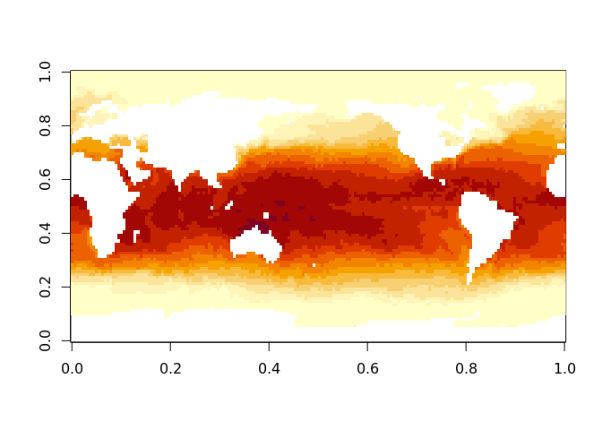

```r
image(oisst_data[[1]])
```

This is exactly the data data provided by `ncdf4::ncvar_get()` or `RNetCDF::var.get.nc()` but we can do it in a single line of code without finding the variable names and looping over them. We automatically get variables from the largest grid that is available, `activate()`-d by default.

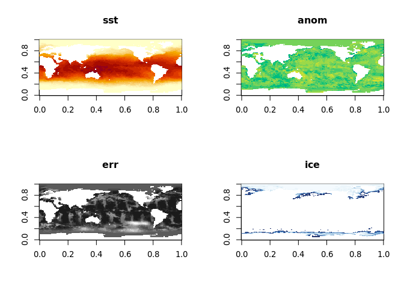

```r
oisst_data <- tidync(oisstfile) %>% hyper_array()
op <- par(mfrow = n2mfrow(length(oisst_data)))
pals <- c("YlOrRd", "viridis", "Grays", "Blues")
for (i in seq_along(oisst_data)) {
  image(oisst_data[[i]], main = names(oisst_data)[i], col = hcl.colors(20, pals[i], rev = i ==1))
}
```

```r
par(op)
```

### Transforms

We have done nothing with the spatial side of these data, ignoring the lon and lat values completely.

```r
oisst_data
```

```
## Class: tidync_data (list of tidync data arrays)
## Variables (4): 'sst', 'anom', 'err', 'ice'
## Dimension (2): lon,lat,zlev,time (180, 90)
## Source: /perm_storage/home/mdsumner/R/x86_64-pc-linux-gnu-library/3.6/stars/nc/reduced.nc
```

```r
lapply(oisst_data, dim)
```

```
## $sst
## [1] 180  90
##
## $anom
## [1] 180  90
##
## $err
## [1] 180  90
##
## $ice
## [1] 180  90
```

The print summary of the `oisst_data` object shows that it knows there are four variable and that they each have 2 dimensions (zlev and time were *dropped*), this is now stored as a list of native R arrays, but there is also the transforms attribute available with `hyper_transforms()`.

The values on each transform table may be used directly.

```r
(trans <- attr(oisst_data, "transforms"))
```

```
## $lon
## # A tibble: 180 x 6
##      lon index    id name  coord_dim selected
##    <dbl> <int> <int> <chr> <lgl>     <lgl>
##  1     0     1     0 lon   TRUE      TRUE
##  2     2     2     0 lon   TRUE      TRUE
##  3     4     3     0 lon   TRUE      TRUE
##  4     6     4     0 lon   TRUE      TRUE
##  5     8     5     0 lon   TRUE      TRUE
##  6    10     6     0 lon   TRUE      TRUE
##  7    12     7     0 lon   TRUE      TRUE
##  8    14     8     0 lon   TRUE      TRUE
##  9    16     9     0 lon   TRUE      TRUE
## 10    18    10     0 lon   TRUE      TRUE
## # … with 170 more rows
##
## $lat
## # A tibble: 90 x 6
##      lat index    id name  coord_dim selected
##    <dbl> <int> <int> <chr> <lgl>     <lgl>
##  1   -89     1     1 lat   TRUE      TRUE
##  2   -87     2     1 lat   TRUE      TRUE
##  3   -85     3     1 lat   TRUE      TRUE
##  4   -83     4     1 lat   TRUE      TRUE
##  5   -81     5     1 lat   TRUE      TRUE
##  6   -79     6     1 lat   TRUE      TRUE
##  7   -77     7     1 lat   TRUE      TRUE
##  8   -75     8     1 lat   TRUE      TRUE
##  9   -73     9     1 lat   TRUE      TRUE
## 10   -71    10     1 lat   TRUE      TRUE
## # … with 80 more rows
##
## $zlev
## # A tibble: 1 x 6
##    zlev index    id name  coord_dim selected
##   <dbl> <int> <int> <chr> <lgl>     <lgl>
## 1     0     1     2 zlev  TRUE      TRUE
##
## $time
## # A tibble: 1 x 6
##    time index    id name  coord_dim selected
##   <dbl> <int> <int> <chr> <lgl>     <lgl>
## 1  1460     1     3 time  TRUE      TRUE
```

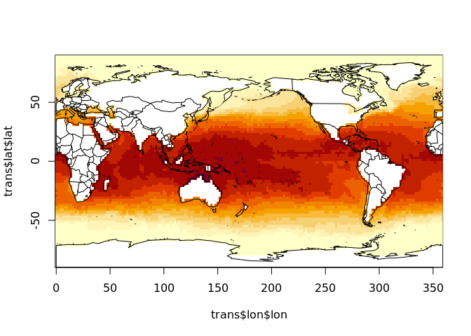

```r
image(trans$lon$lon, trans$lat$lat,  oisst_data[[1]])
maps::map("world2", add = TRUE)
```

In this case these *transforms* are somewhat redundant, there is a value stored for every step in `lon` and every step in `lat` and they are completely regular, whereas the usual approach in graphics is to store an *offset and scale* rather than each dimension’s coordinate. Sometimes though these coordinate values are not reducible this way and we would call them *rectilinear* (we have to store the sequence of each 1D coordinate dimension).

### Slicing

We can slice into these dimensions using a tidyverse approach. For example, say we wanted to slice out only the data for the waters of the Pacific Ocean, we need a range in longitude and a range in latitude.

#### Old style slicing

This section illustrates the old laborious way to access a subset of data from NetCDF.

We can put these ranges directly on our raw plot from earlier.

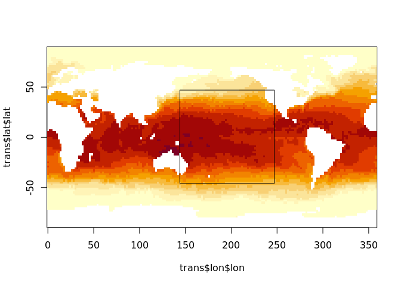

```r
lonrange <- c(144, 247)
latrange <- c(-46, 47)

image(trans$lon$lon, trans$lat$lat,  oisst_data[[1]])
rect(lonrange[1], latrange[1], lonrange[2], latrange[2])
```

It’s common on the internet to see posts that explain how to drive the NetCDF library with *start* and *count* indices, to do that we need to compare our ranges with the *transforms* of each dimension.

```r
xs <- findInterval(lonrange, trans$lon$lon)
ys <- findInterval(latrange, trans$lat$lat)
print(xs)
```

```
## [1]  73 124
```

```r
print(ys)
```

```
## [1] 22 69
```

```r
start <- c(xs[1], ys[1])
count <- c(diff(xs), diff(ys))

print(start)
```

```
## [1] 73 22
```

```r
print(count)
```

```
## [1] 51 47
```

The idea here is that `xs` and `ys` tell us the columns and rows of interest, based on our geographic input in longitude latitude values that we understand.

Let’s try to read with NetCDF. Hmmm …. what goes wrong.

```r
con <- RNetCDF::open.nc(oisstfile)
try(sst_matrix <- RNetCDF::var.get.nc(con, "sst", start = start, count = count))
```

```
## Error in RNetCDF::var.get.nc(con, "sst", start = start, count = count) :
##   length(start) == ndims is not TRUE
```

We have been bitten by thinking that this source data are 2D! So we just add start and count of 1 for each extra dimension (but what if it was 3D, or 5D, or time comes first - all of these things complicate these *simple solutions*).

```r
start <- c(start, 1, 1)
count <- c(count, 1, 1)
sst_matrix <- RNetCDF::var.get.nc(con, "sst", start = start, count = count)
```

And we’re good! Except, we now don’t have the coordinates for the mapping. We have to slice the lon and lat values as well, but let’s cut to the chase and go back to tidync.

#### tidync style slicing

Rather than slice the arrays read into memory, we can *filter* the object that understands the source and it does *not do any data slicing at all*, but records slices *to be done in future*. This is the lazy beauty of the tidyverse, applied to NetCDF.

Here we used `between()` for lon and standard R inequality syntax for lat simply to show that both kinds of expression are available. *We don’t have to specify the redundant slice into zlev or time*.

```r
library(dplyr)
oisst_slice <- oisst %>% hyper_filter(lon = between(lon, lonrange[1], lonrange[2]),
                       lat = lat > latrange[1] & lat <= latrange[2])

oisst_slice
```

```
##
## Data Source (1): reduced.nc ...
##
## Grids (5) <dimension family> : <associated variables>
##
## [1]   D0,D1,D2,D3 : sst, anom, err, ice    **ACTIVE GRID** ( 16200  values per variable)
## [2]   D0          : lon
## [3]   D1          : lat
## [4]   D2          : zlev
## [5]   D3          : time
##
## Dimensions 4 (all active):
##
##   dim   name  length   min   max start count  dmin  dmax unlim coord_dim
##   <chr> <chr>  <dbl> <dbl> <dbl> <int> <int> <dbl> <dbl> <lgl> <lgl>
## 1 D0    lon      180     0   358    73    52   144   246 FALSE TRUE
## 2 D1    lat       90   -89    89    23    47   -45    47 FALSE TRUE
## 3 D2    zlev       1     0     0     1     1     0     0 FALSE TRUE
## 4 D3    time       1  1460  1460     1     1  1460  1460 TRUE  TRUE
```

The print summary has updated the `start` and `count` columns now to match our laboriously acquired versions above (they are slightly different because of the difference between `findInterval()` and our inequality expressions).

The `dmin` and `dmax` (data-min, data-max) columns are also updated, reporting the coordinate value at the start and end of the slice we have specified.

Now we can break the lazy chain and call for the data.

```r
oisst_slice_data <- oisst_slice %>% hyper_array()
trans <- attr(oisst_slice_data, "transforms")
```

One unfortunate issue here is that we cannot use the transforms directly, they *have* been updated but not in the obvious way (this is something that should probably be fixed in tidync).

First filter the lon and lat transforms based on the `selected` column.

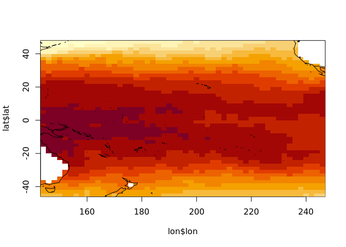

```r
lon <- trans$lon %>% dplyr::filter(selected)
lat <- trans$lat %>% dplyr::filter(selected)

image(lon$lon, lat$lat, oisst_slice_data[[1]])
maps::map("world2", add = TRUE)
```

It is extra work with `hyper_array()` but it does give total control over what we can get.

It’s much easier to use other output types.

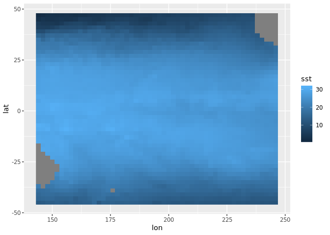

```r
tcube <- tidync(oisstfile) %>%
  hyper_filter(lon = between(lon, lonrange[1], lonrange[2]),
                       lat = lat > latrange[1] & lat <= latrange[2]) %>%
  hyper_tbl_cube()

library(ggplot2)
ggplot(as_tibble(tcube)) + geom_raster(aes(lon, lat, fill = sst))
```

For those that prefer old-school ggplot2 we can read our slice in directly as a tibble.

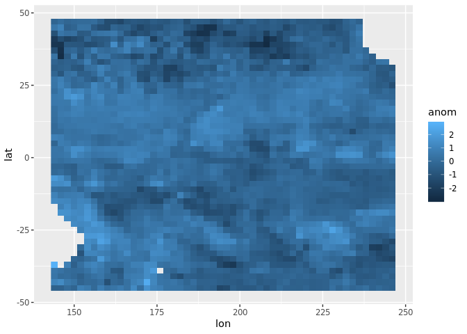

```r
tdata <- tidync(oisstfile) %>%
  hyper_filter(lon = between(lon, lonrange[1], lonrange[2]),
                       lat = lat > latrange[1] & lat <= latrange[2]) %>%
  hyper_tibble()

ggplot(tdata, aes(lon, lat, fill = anom)) + geom_raster()
```

By default, all variables are available but we can limit with `select_var`.

```r
tidync(oisstfile) %>%
  hyper_filter(lon = between(lon, lonrange[1], lonrange[2]),
                       lat = lat > latrange[1] & lat <= latrange[2]) %>%
  hyper_tibble(select_var = c("err", "ice"))
```

```
## # A tibble: 2,377 x 6
##      err   ice   lon   lat  zlev  time
##    <dbl> <dbl> <dbl> <dbl> <dbl> <dbl>
##  1 0.230    NA   144   -45     0  1460
##  2 0.320    NA   146   -45     0  1460
##  3 0.280    NA   148   -45     0  1460
##  4 0.210    NA   150   -45     0  1460
##  5 0.200    NA   152   -45     0  1460
##  6 0.240    NA   154   -45     0  1460
##  7 0.230    NA   156   -45     0  1460
##  8 0.250    NA   158   -45     0  1460
##  9 0.260    NA   160   -45     0  1460
## 10 0.290    NA   162   -45     0  1460
## # … with 2,367 more rows
```

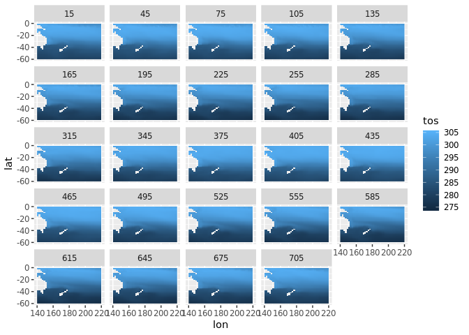

```r
tos <- tidync(system.file("nc/tos_O1_2001-2002.nc", package = "stars"))
library(dplyr)
stos <- tos %>% hyper_filter(lon = between(lon, 140, 220),
                     lat = between(lat, -60, 0)) %>% hyper_tibble()

library(ggplot2)
ggplot(stos, aes(lon, lat, fill = tos)) + geom_raster() + facet_wrap(~time)
```

### Limitations

There are some limitations, specific to the tidync R package that are unrelated to the capabilities of the latest NetCDF library.

- No groups, a group can be specified by providing the group-within-a-source *as a source*.
- No compound types.
- No attribute metadata, coordinates of 1D axes are stored as *transform tables*, but coordinates of pairs (or higher sets) of axes are not explicitly linked to their array data.
- Curvilinear coordinates are not automatically expanded, this is because they exist (usually) on a different grid to the active one.
- Unknowns about what is supported on what platforms. This is surprisingly tricky and unstable, there are a lot of things that are possible on one operating system at a given time, but not on others. The situtation changes fairly slowly but is always changing due to library versions and releases, package and tooling support on CRAN, and operating system details.

If you have problems with a given source please get in touch so we can learn more about the overall landscape.

### Future helpers

#### Coordinate expansion

A feature being considered for an upcoming version is to expand out all available linked coordinates. This occurs when an array has a dimension but only stores its index. When a dimension stores values directly this is known as a *dim-coord*, and usually occurs for time values. One way to expand this out would be to include an `expand_coords` argument to `hyper_tibble()` and have it run the following code:

```r
#' Expand coordinates stored against dimensions
#'
#' @param x tidync object
#' @param ... ignored
#'
#' @return data frame of all variables and any linked-coordinates
#' @noRd
#'
#' @examples

full_expand <- function(x, ...) {
  ad <- active(x)
  spl <- strsplit(ad, ",")[[1L]]
  out <- hyper_tibble(x)

  for (i in seq_along(spl)) {
    out <- dplyr::inner_join(out, activate(x, spl[i]) %>% hyper_tibble())
  }
  out
}
```

It’s not clear to me how consistently this fits in the wider variants found in the NetCDF world, so any feedback is welcome.

A real world example is available in the `ncdfgeom` package. This package provides much more in terms of storing geometry within a NetCDF file, but here we only extract the lon, lat and station name that `hyper_tibble()` isn’t seeing by default.

```r
huc <- system.file('extdata','example_huc_eta.nc', package = 'ncdfgeom')

full_expand(tidync(huc))
```

```
## # A tibble: 50 x 5
##       et  time station   lat   lon
##    <int> <dbl>   <int> <dbl> <dbl>
##  1    10 10957       1  36.5 -80.4
##  2    19 10988       1  36.5 -80.4
##  3    21 11017       1  36.5 -80.4
##  4    36 11048       1  36.5 -80.4
##  5   105 11078       1  36.5 -80.4
##  6   110 11109       1  36.5 -80.4
##  7   128 11139       1  36.5 -80.4
##  8   121 11170       1  36.5 -80.4
##  9    70 11201       1  36.5 -80.4
## 10    25 11231       1  36.5 -80.4
## # … with 40 more rows
```

```r
hyper_tibble(tidync(huc))
```

```
## # A tibble: 50 x 3
##       et  time station
##    <int> <dbl>   <int>
##  1    10 10957       1
##  2    19 10988       1
##  3    21 11017       1
##  4    36 11048       1
##  5   105 11078       1
##  6   110 11109       1
##  7   128 11139       1
##  8   121 11170       1
##  9    70 11201       1
## 10    25 11231       1
## # … with 40 more rows
```

#### Tidy approaches to other data sources

This approach could be applied to other array-based data systems, such as the [ff package](https://CRAN.r-project.org/package=ff), the [matter package](https://CRAN.r-project.org/package=matter) GDAL raster or [multi-dimensional](https://gdal.org/tutorials/index.html#multidimensional-raster) data sources, and [HDF5](https://www.hdfgroup.org/solutions/hdf5/) or GRIB sources.

We have experimented with this for non-NetCDF formats, please get in touch if you are interested.

The [stars project](https://github.com/r-spatial/stars/) takes another perspective on a tidy approach to scientific array data, it’s very high-level and may be a drop-in solution for your workflow so I’d recommend trying it as well.

### rOpenSci package review

The `tidync` package made it to CRAN after a fairly long review process on [rOpenSci](https://github.com/ropensci/software-review/issues/174). In early 2018 I really wasn’t sure if it could be finished at all in a neat way and was a bit overwhelmed, but thanks to very helpful reviewers and also some key insights about [obscure types](https://github.com/ropensci/tidync/issues/75#issuecomment-468064627) it was done. The package benefitted greatly from feedback provided by [Jakub Nowosad](https://github.com/Nowosad) and [Tim Lucas](https://github.com/timcdlucas). I really appreciated the clarity provided by these reviews, it really helped to finalize some design decisions on the naming of functions and their intended use. There are various aspects that I thought were obstacles in completing the project, and having reviews that did not share my concerns and also gave positive feedback and suggestions for more relevant changes was extremely helpful.

Thanks also to [rOpenSci](https://ropensci.org/) community members for encouragement and support!